# Data Science Specialization - Project 8

Jakub Vedral

23th June 2017

## Introduction

The goal of this project is to predict the manner in which participants performed Weight Lifting Exercise (http://groupware.les.inf.puc-rio.br/har). Participants in this experiment wore accelerometers on the belt, forearm, arm, and dumbell of 6 participants. They were asked to perform barbell lifts correctly and incorrectly in 5 different ways. Our task is to build a model which will predict what was the way participants moved (ie. quality of the excercise).

## Analysis

At first lets download and load the dataset:

```r
download.file("https://d396qusza40orc.cloudfront.net/predmachlearn/pml-training.csv", destfile = "pml-training.csv")
download.file("https://d396qusza40orc.cloudfront.net/predmachlearn/pml-testing.csv", destfile = "pml-testing.csv")

train <- read.csv("pml-training.csv",na.strings = c("NA",""))
test <- read.csv("pml-testing.csv",na.strings = c("NA",""))
```

As we can see, the dataset is quite rich in data in terms of rows and possible features.

```r
dim(train)
```

```
## [1] 19622   160
```

Now we try to build a model predicting the “classe” variable in the training set. This variable tells us the way of move.

Before we approach to model training let’s first explore the dataset a bit using data profiling library “dataQualityR”.

```r
library(dataQualityR)
checkDataQuality(train, out.file.num = "dq_n.csv", out.file.cat = "dq_c.csv")
```

```
## Check for numeric variables completed // Results saved to disk // Time difference of 0.837079 secs
## Check for categorical variables completed // Results saved to disk // Time difference of 0.304019 secs
```

This package will automatically show us basic statistic (much like summary function). But what is handy is that it will print it in tabular layout. Two files are created: * “dq_n.csV” for numeric data * “dq_c.csV” for categorical data

Lets load them and look at them

```r
dq_n <- read.csv("dq_n.csv")
dq_c <- read.csv("dq_c.csv")

head(dq_n, n= 30)
```

```
##                       X non.missing missing missing.percent unique
## 1                     X       19622       0            0.00  19622
## 2  raw_timestamp_part_1       19622       0            0.00    837
## 3  raw_timestamp_part_2       19622       0            0.00  16783
## 4            num_window       19622       0            0.00    858
## 5             roll_belt       19622       0            0.00   1330
## 6            pitch_belt       19622       0            0.00   1840
## 7              yaw_belt       19622       0            0.00   1957
## 8      total_accel_belt       19622       0            0.00     29
## 9         max_roll_belt         406   19216           97.93    196
## 10       max_picth_belt         406   19216           97.93     23
## 11        min_roll_belt         406   19216           97.93    185
## 12       min_pitch_belt         406   19216           97.93     17
## 13  amplitude_roll_belt         406   19216           97.93    149
## 14 amplitude_pitch_belt         406   19216           97.93     14
```

[output cut: 109 more lines]

```r
head(dq_c, n= 30)
```

```
##                          X n.non.miss n.miss n.miss.percent n.unique
## 1                user_name      19622      0           0.00        6
## 2           cvtd_timestamp      19622      0           0.00       20
## 3               new_window      19622      0           0.00        2
## 4       kurtosis_roll_belt        406  19216          97.93      397
## 5      kurtosis_picth_belt        406  19216          97.93      317
## 6        kurtosis_yaw_belt        406  19216          97.93        2
## 7       skewness_roll_belt        406  19216          97.93      395
## 8     skewness_roll_belt.1        406  19216          97.93      338
## 9        skewness_yaw_belt        406  19216          97.93        2
## 10            max_yaw_belt        406  19216          97.93       68
## 11            min_yaw_belt        406  19216          97.93       68
## 12      amplitude_yaw_belt        406  19216          97.93        4
## 13       kurtosis_roll_arm        406  19216          97.93      330
## 14      kurtosis_picth_arm        406  19216          97.93      328
```

[output cut: 140 more lines]

As we can see there are columns with over 90% of missing values. If we look closely, we will find out that these are aggegations/summaries of previous timestamps. We can try two approaches: 1) fill in the missing values with the last known value. We will then repeate this value until it “changes”. 2) dont use those columns in our prediction model

I prefer second option, becouse aggregations/summaries will tend to be highly correlated with the original non-aggregated columns.

Also it would be reasonable to remove timestamp columns (given that we dont change order) and user_name as it can hardly contribute to predictions of current move.

```r
train_adj <- train[ , colSums(is.na(train)) == 0]
train_adj <- train_adj[ , -c(1:5)]
```

Now lets check correlations among columns. It is good practice to remove highly correlated columns as they add little value to model. (we exclude factor variablesfrom the analysis and “classe” column- as it is predicted value)

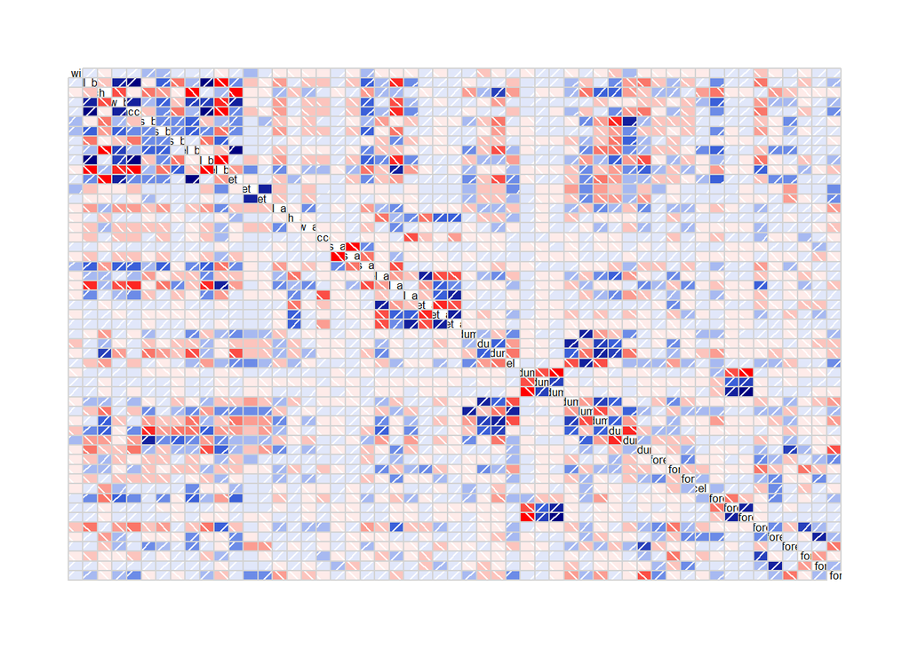

```r
library(corrgram)
corrgram(train_adj)
```

We can see that there are some (evne strong) correlations, but there is no columns highly correlated to all other columns. I think we can use all of them in our prediction.

Lets do it.

```r
library(caret)
library(lubridate)
set.seed(154)
train_control<- trainControl(method="cv", number=20)
train_control2<- trainControl(method="cv", number=10)
train_control3<- trainControl(method="cv", number=5)
train_control4<- trainControl(method="cv", number=2)

modFit1_start_ts <- now()
modFit1 <- train(classe ~ . , method ="rpart",data= train_adj , trControl=train_control)
modFit1_end_ts <-now()
modFit1_duration <- modFit1_end_ts - modFit1_start_ts

modFit2_start_ts <- now()
modFit2 <- train(classe ~ . , method ="kknn",data= train_adj , trControl=train_control, k = 5)
modFit2_end_ts <- now()
modFit2_duration <- modFit2_end_ts - modFit2_start_ts

modFit3_start_ts <- now()
modFit3 <- train(classe ~ . , method ="kknn",data= train_adj , trControl=train_control2, k = 5)
modFit3_end_ts <- now()
modFit3_duration <- modFit3_end_ts - modFit3_start_ts

modFit4_start_ts <- now()
modFit4 <- train(classe ~ . , method ="kknn",data= train_adj , trControl=train_control3, k = 5)
modFit4_end_ts <- now()
modFit4_duration <- modFit4_end_ts - modFit4_start_ts

modFit5_start_ts <- now()
modFit5 <- train(classe ~ . , method ="kknn",data= train_adj , trControl=train_control4 , k = 5)
modFit5_end_ts <- now()
modFit5_duration <- modFit5_end_ts - modFit5_start_ts

modFit1
```

```
## CART
##
## 19622 samples
##    54 predictor
##     5 classes: 'A', 'B', 'C', 'D', 'E'
##
## No pre-processing
## Resampling: Cross-Validated (20 fold)
## Summary of sample sizes: 18641, 18641, 18641, 18640, 18642, 18641, ...
## Resampling results across tuning parameters:
##
##   cp          Accuracy   Kappa
##   0.03891896  0.5309414  0.39531015
##   0.05998671  0.4070741  0.19441416
##   0.11515454  0.3145018  0.04592997
##
## Accuracy was used to select the optimal model using  the largest value.
## The final value used for the model was cp = 0.03891896.
```

At first I tried prediction with classification tree, but the accuracy was low only 53% and the tree did not classify to all the possible outcomes (missing “D”classe in prediction), though it took a little time to train (13 seconds). I chose 20-fold cross valiation. This number should have brought reasonable reduction of variance without much increasing the bias. In the end it did not matter, becouse of the low accuracy.

```r
modFit1$finalModel
```

```
## n= 19622
##
## node), split, n, loss, yval, (yprob)
##       * denotes terminal node
##
##  1) root 19622 14042 A (0.28 0.19 0.17 0.16 0.18)
##    2) roll_belt< 130.5 17977 12411 A (0.31 0.21 0.19 0.18 0.11)
##      4) pitch_forearm< -33.95 1578    10 A (0.99 0.0063 0 0 0) *
##      5) pitch_forearm>=-33.95 16399 12401 A (0.24 0.23 0.21 0.2 0.12)
##       10) magnet_dumbbell_y< 439.5 13870  9953 A (0.28 0.18 0.24 0.19 0.11)
##         20) roll_forearm< 123.5 8643  5131 A (0.41 0.18 0.18 0.17 0.061) *
##         21) roll_forearm>=123.5 5227  3500 C (0.077 0.18 0.33 0.23 0.18) *
##       11) magnet_dumbbell_y>=439.5 2529  1243 B (0.032 0.51 0.043 0.22 0.19) *
##    3) roll_belt>=130.5 1645    14 E (0.0085 0 0 0 0.99) *
```

```r
results<- data.frame( accuracy= c(
  modFit2$results$Accuracy[1],
  modFit3$results$Accuracy[1],
  modFit4$results$Accuracy[1],
  modFit5$results$Accuracy[1]),
  duration = c(modFit2_duration,
               modFit3_duration,
               modFit4_duration,
               modFit5_duration)
  )
results
```

```
##    accuracy       duration
## 1 0.9862397 738.89751 secs
## 2 0.9858834 337.43058 secs
## 3 0.9833349 161.43816 secs
## 4 0.9739579  54.56963 secs
```

```r
predict(modFit5,test)
```

```
##  [1] B A B A A E D B A A B C B A E E A B B B
## Levels: A B C D E
```

Predicted numbers were successfully confirmed in Coursera quiz test.